# Coronavirus v Čechách

# Základní statistiky

## Testy

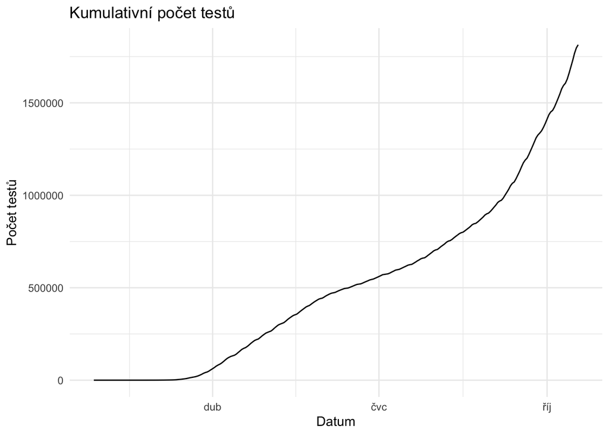

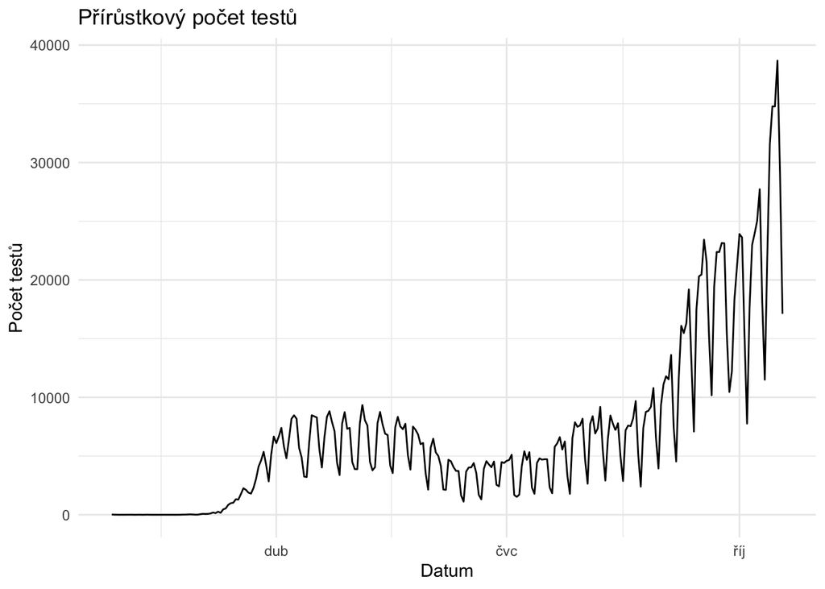

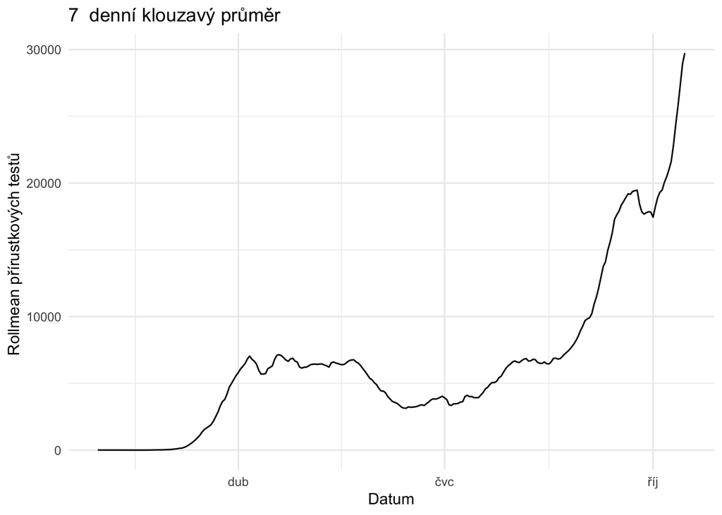

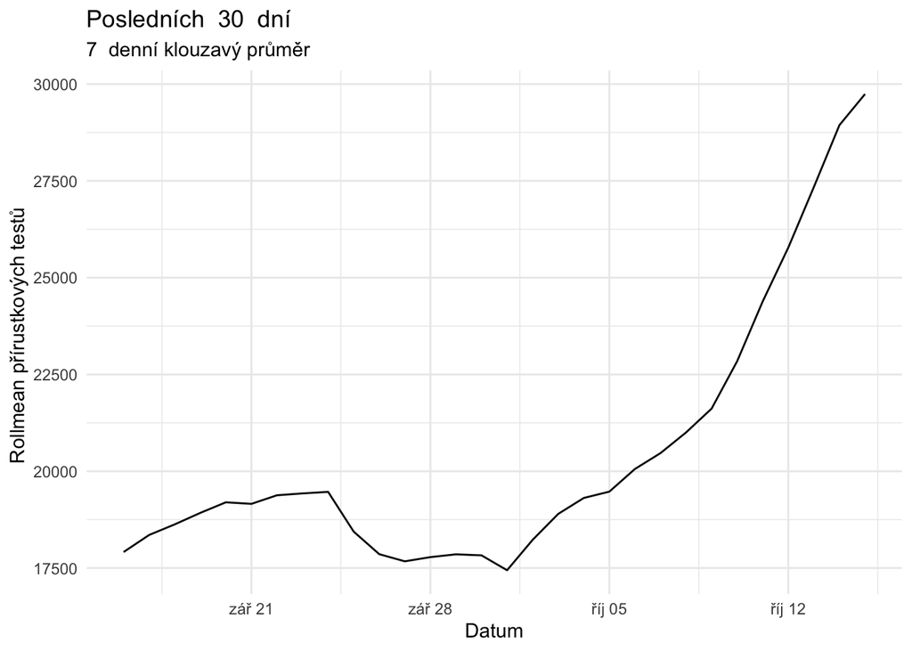

## Pozitivní případy

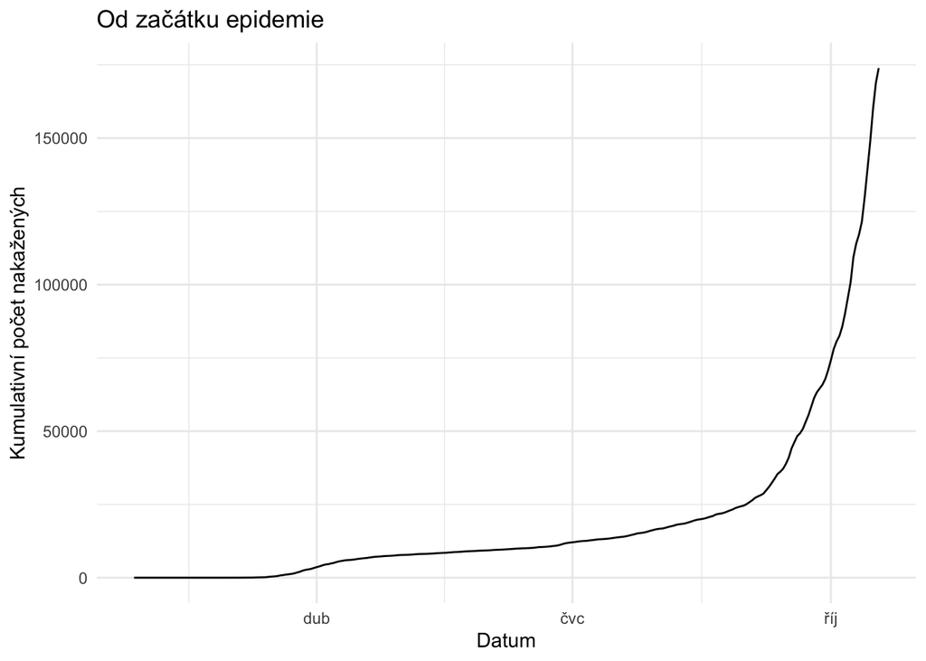

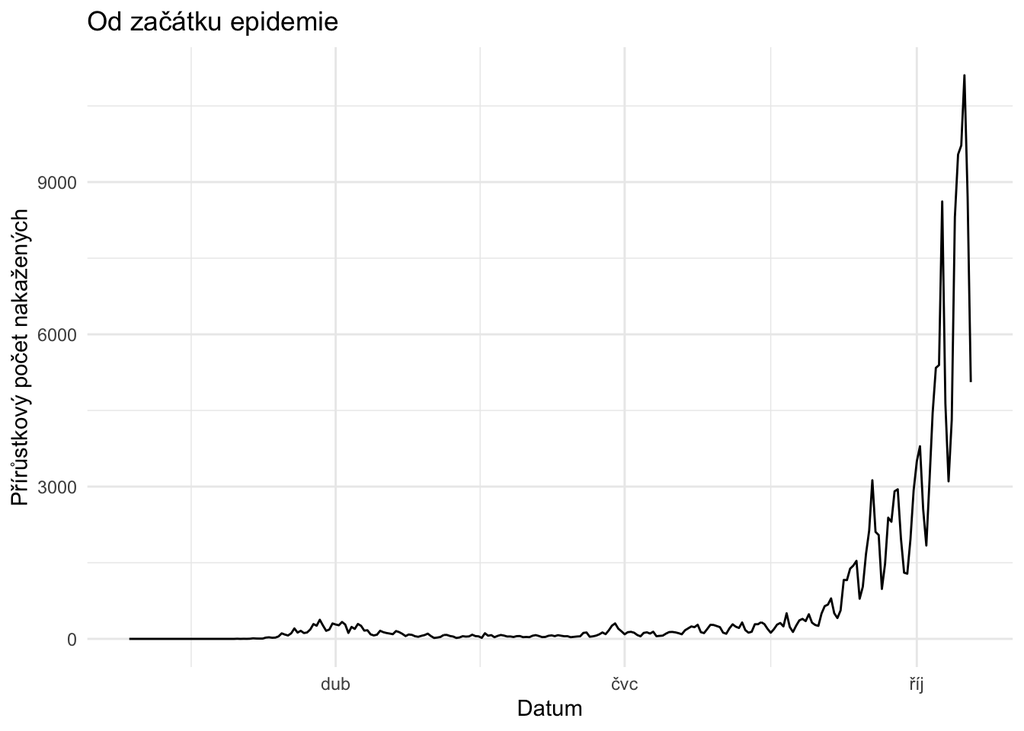

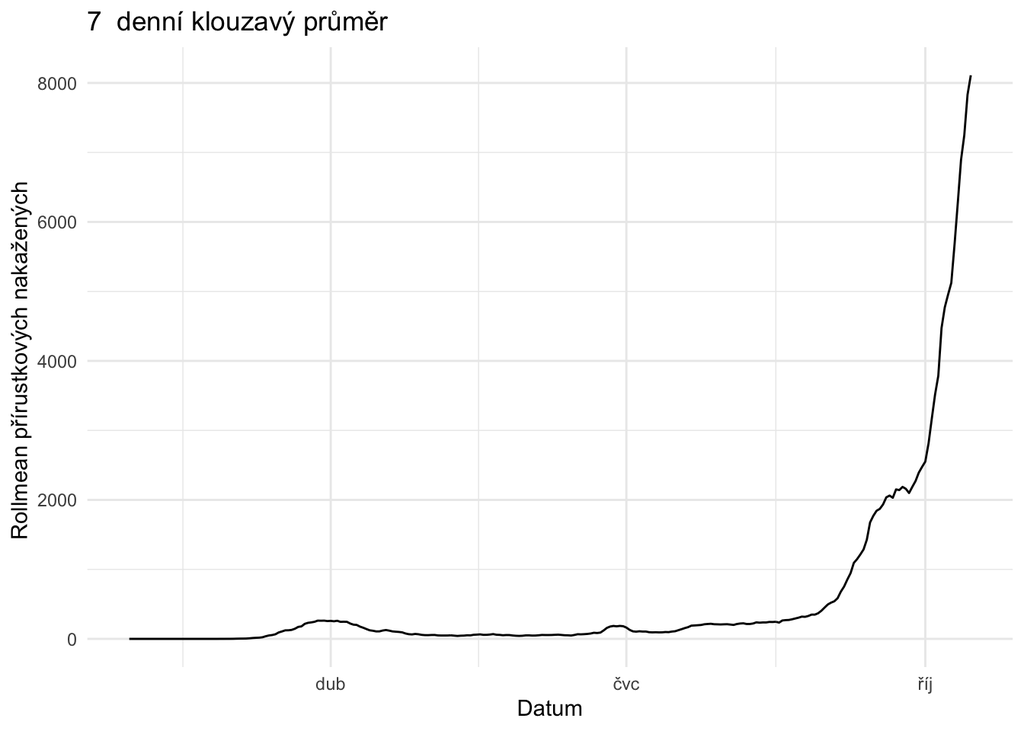

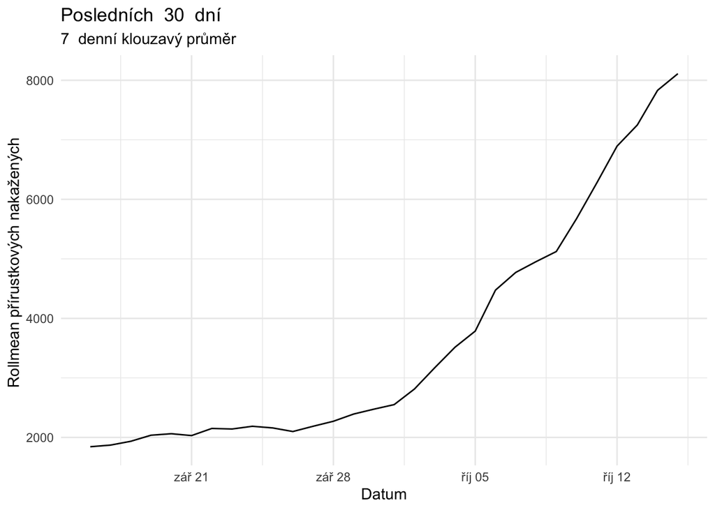

## Podíl pozitivních testů

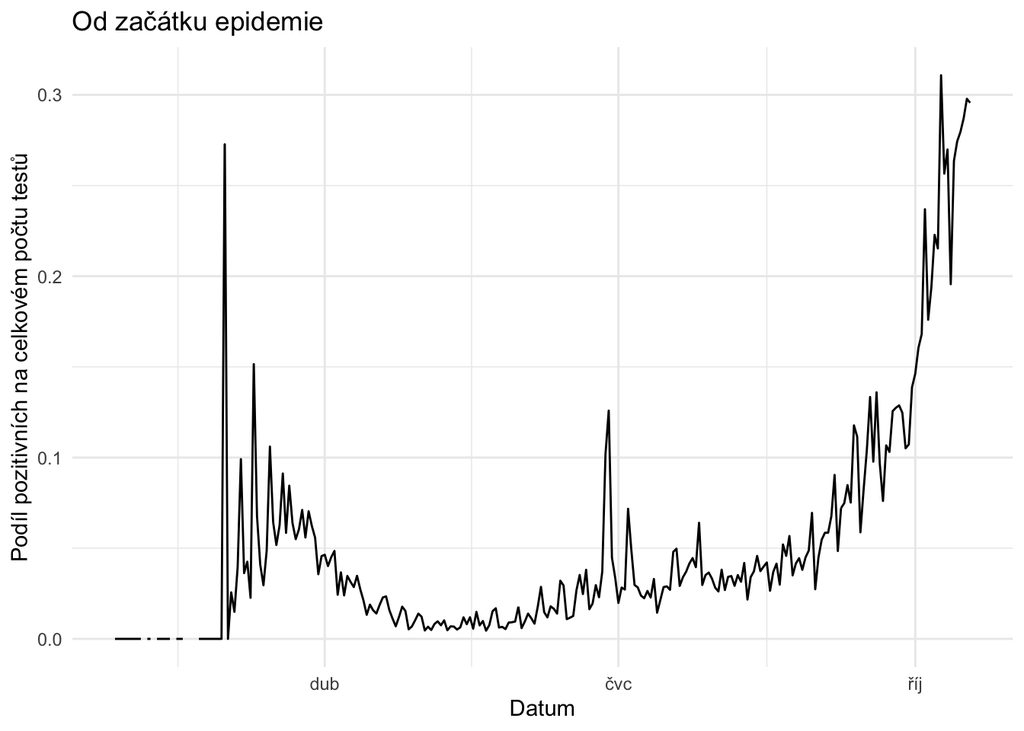

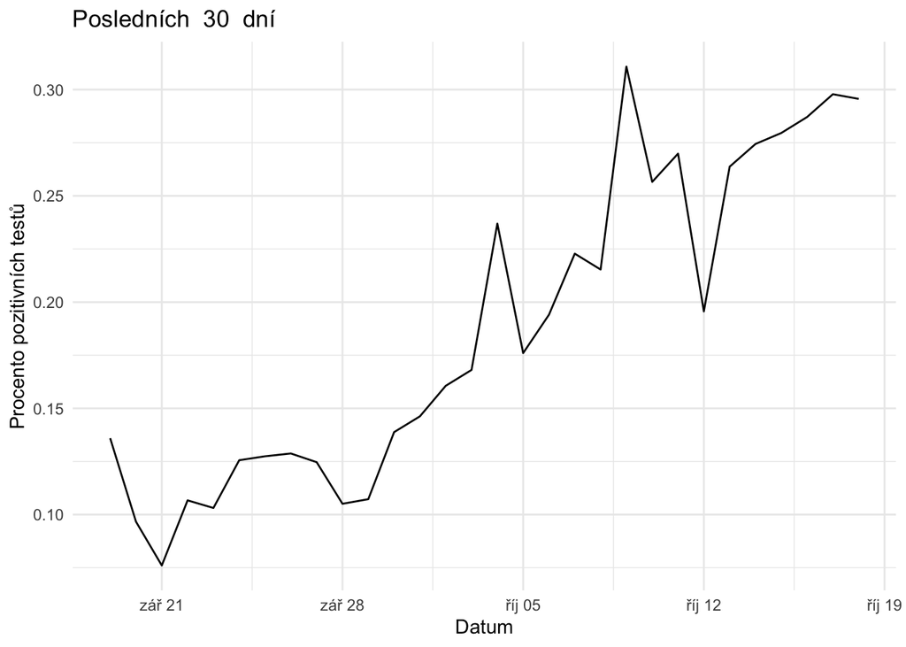

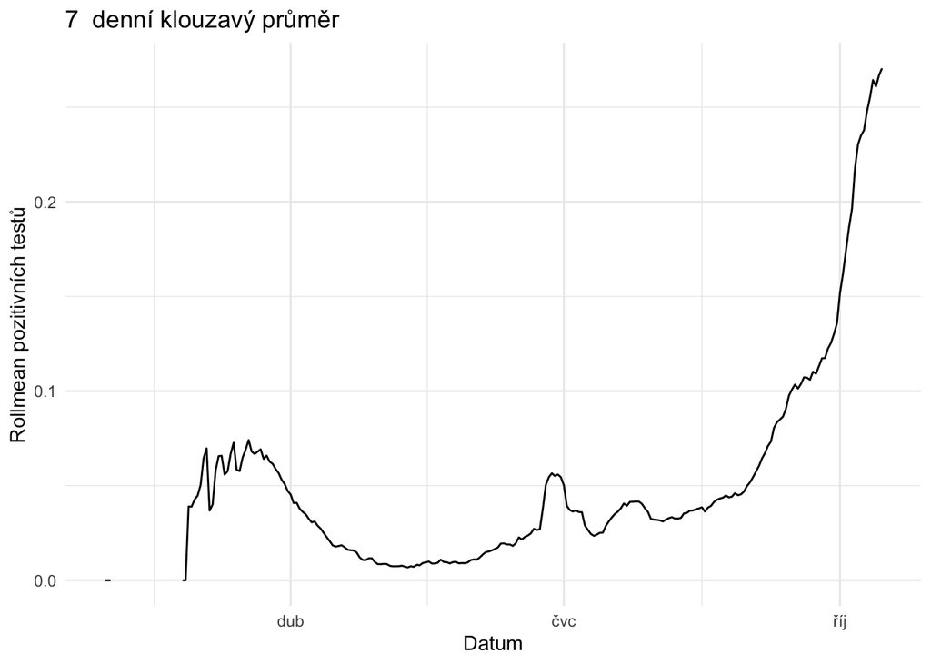

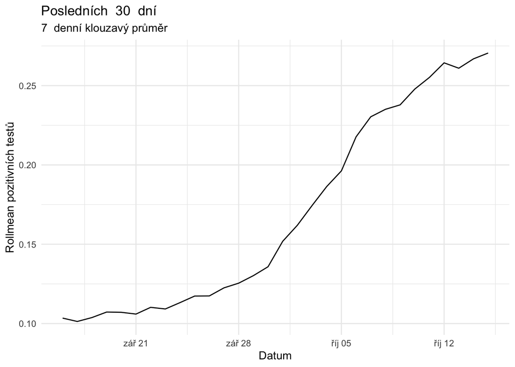

Podíl pozitivních testů na celkovém počtu od začátku epidemie je `9.586` %.

Podíl pozitivních testů na celkovém počtu za posledních 30 dní je `19.981` %.

# Modely

## Linearní model

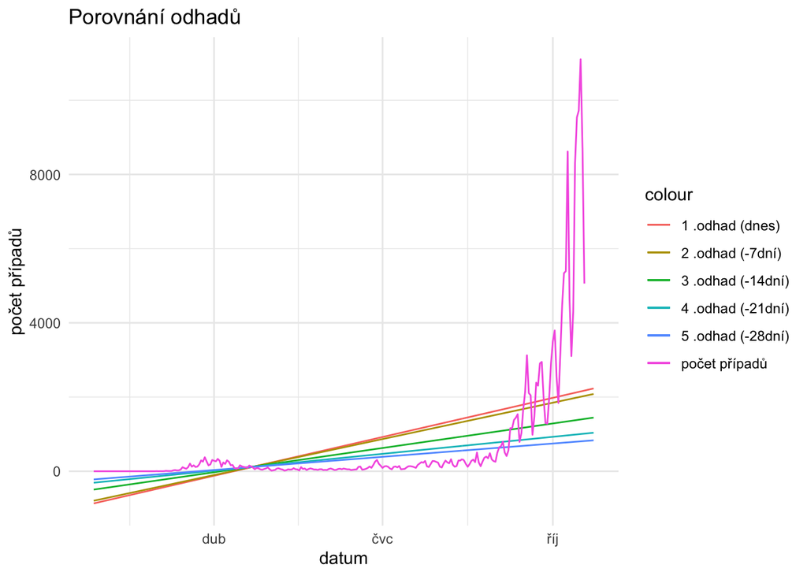

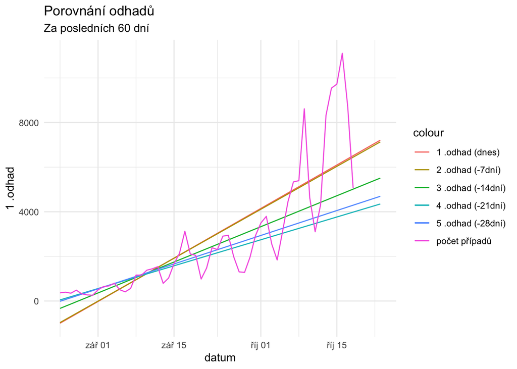

### Data (Lineární model)

#### Od začátku epidemie

Podle lineárního modelu bychom tímto tempem měli dne `2020-10-23` podle

- 1. odhadu `2231` nakažených
- 2. odhadu `2083` nakažených
- 3. odhadu `1446` nakažených
- 4. odhadu `1038` nakažených
- 5. odhadu `833` nakažených

#### Za posledních `60` dní

Podle lineárního modelu bychom tímto tempem měli dne `2020-10-23` podle

- 1. odhadu `7210` nakažených denně
- 2. odhadu `7133` nakažených denně
- 3. odhadu `5510` nakažených denně
- 4. odhadu `4349` nakažených denně
- 5. odhadu `4694` nakažených denně

## Kvadratický model

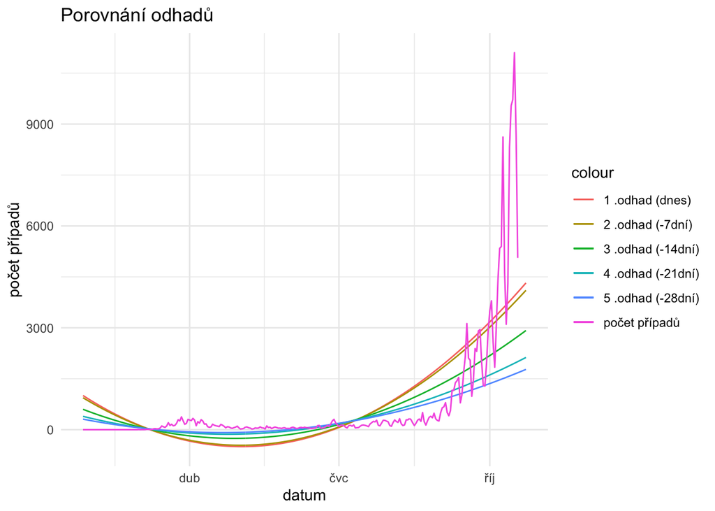

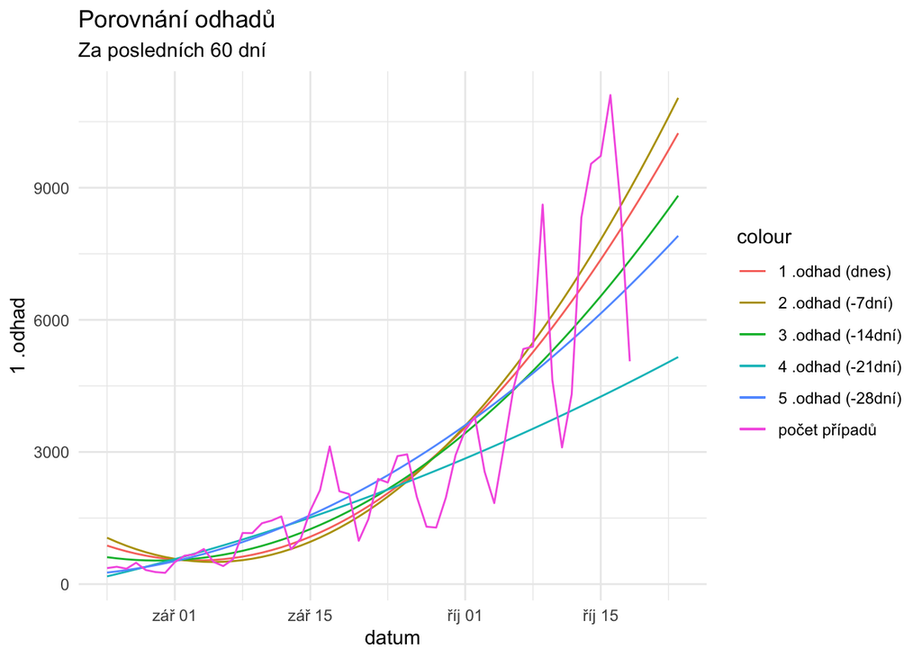

### Data (Kvadratický model)

#### Od začátku epidemie

Podle kvadratického modelu bychom tímto tempem měli dne `2020-10-23` podle

- 1. odhadu `4321` nakažených
- 2. odhadu `4103` nakažených
- 3. odhadu `2920` nakažených
- 4. odhadu `2126` nakažených
- 5. odhadu `1775` nakažených

#### Za posledních `60` dní

- 1. odhadu `10239` nakažených denně
- 2. odhadu `11040` nakažených denně
- 3. odhadu `8819` nakažených denně
- 4. odhadu `5156` nakažených denně
- 5. odhadu `7908` nakažených denně

# SIR MODELY

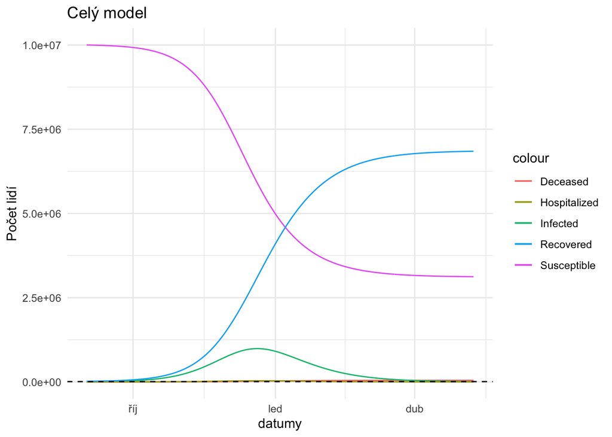

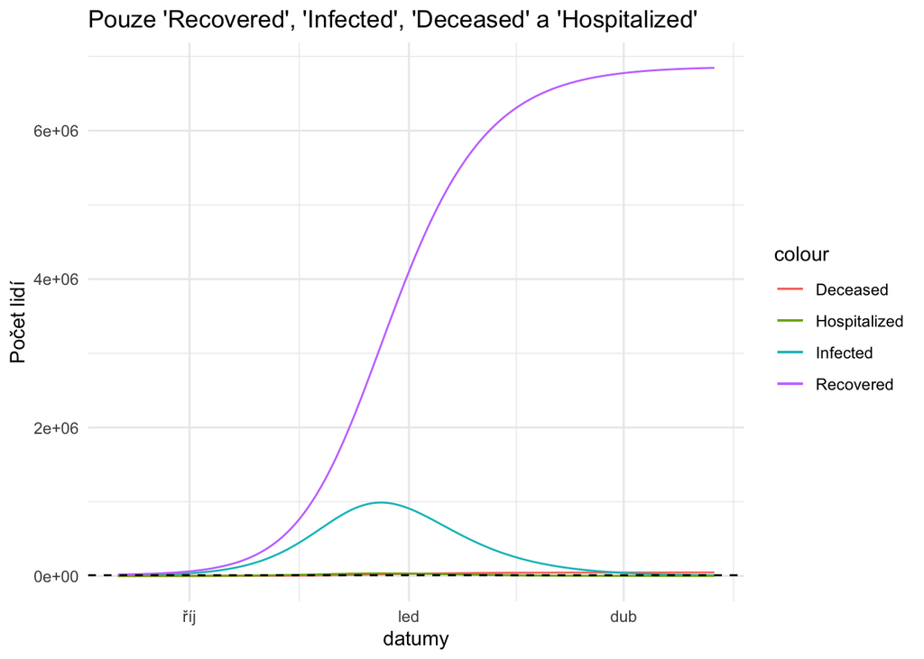

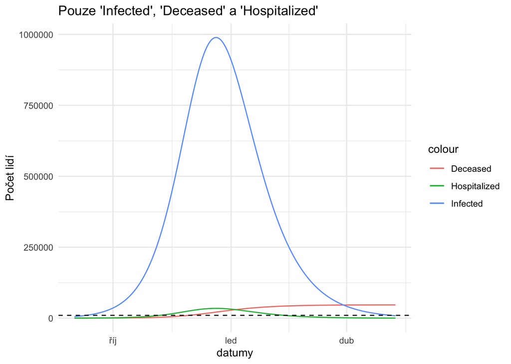

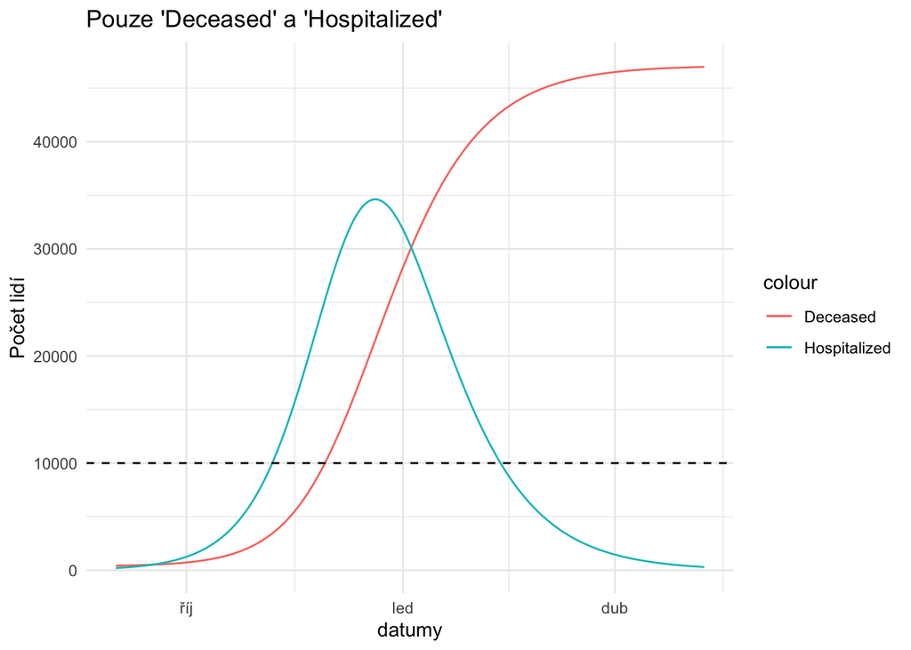

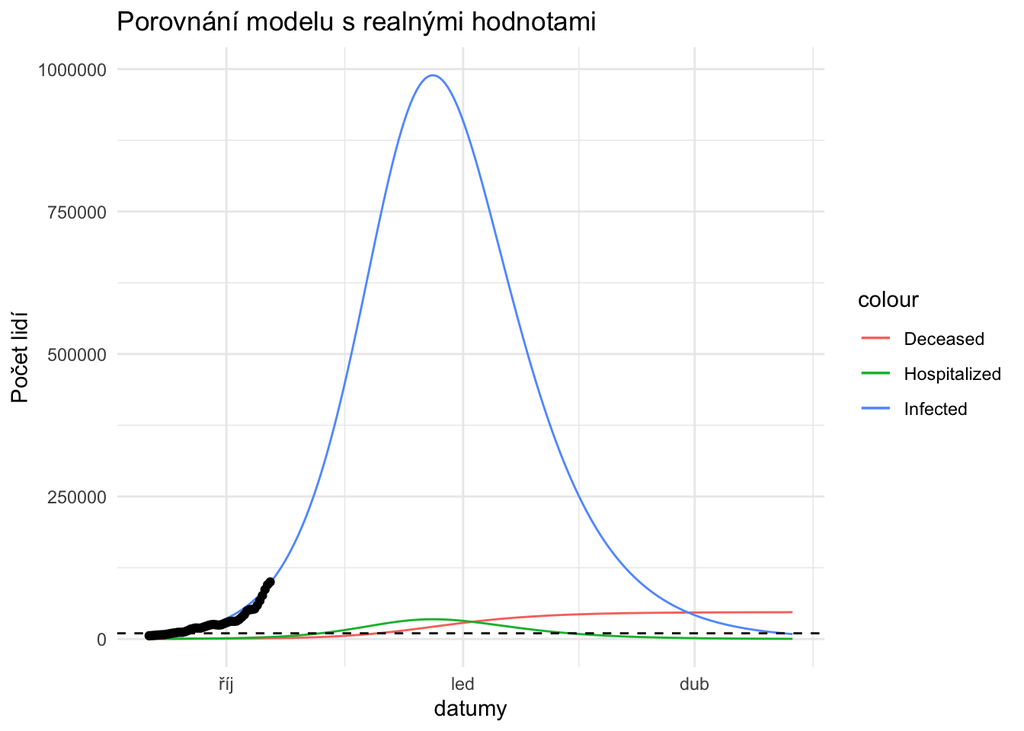

## Informace

`Peak nastane dne 2020-12-20 s počtem nakažených rovnu 989166 a aktuálním počtem hospitalizovných v nemocnicích 34621 lidí.`

`Kapacita nemocnich, která je stanovena na 10000 lůžek, bude při momentálním trendu překročena dne 2020-11-07`

`Celkově Covid-19 prodělá 6846520`

`Počet umrtí se zastaví na čísle 46980`

# Informace

Poslední update proběhl `2020-10-18` ze stránek ministerstva zdravotnictví ČR (https://onemocneni-aktualne.mzcr.cz/covid-19)